# Dealing with Diaspora Dissent in Different Domains

## A Conceptual Framework of Authoritarian Regimes’ Foreign Social Media Strategies

## Allison Koh

[figure not shown]

ipb annual conference  
Freie Universität Berlin  
October 6, 2023

[figure not shown]

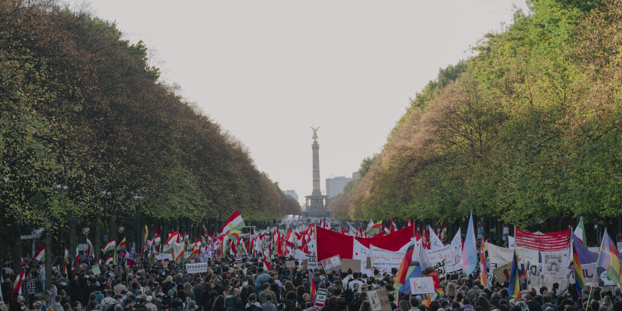

[figure not shown]

[figure not shown]

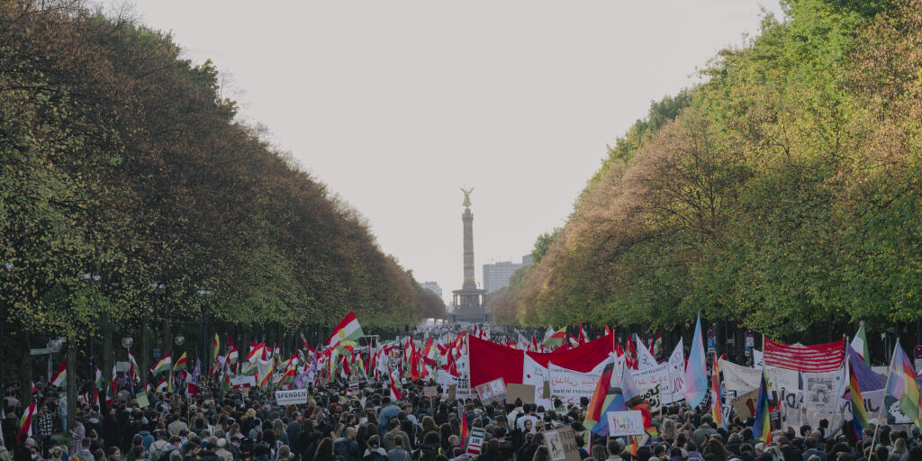

[figure not shown]

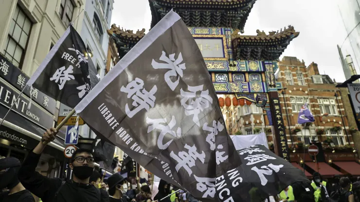

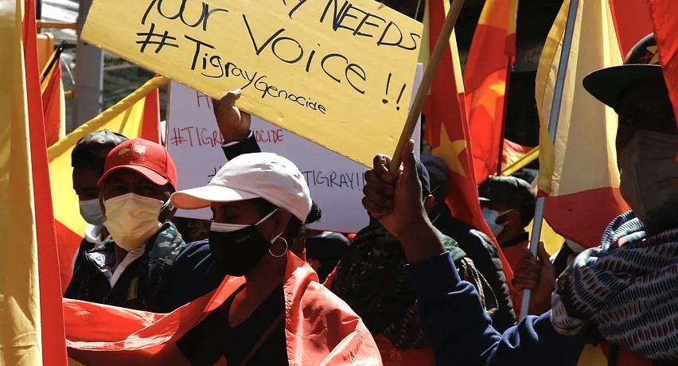

[figure not shown]

## Overview

### Areas of Inquiry

Why do diasporas pose a unique threat to governments engaging in repression?

What resources are available for states to control social media activity?

How do states address diaspora dissent on foreign social media?

### Observable Implications

What data can we use in this research area?

What challenges will researchers face in this area?

## Diasporas as Regime Threats

### What is so threatening about dissent in diasporas?

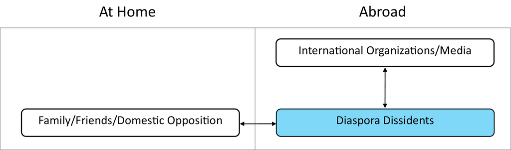

“Horizontal” networks at home 🏡  
(Brinkerhoff 2009; Alonso and Oiarzabal 2010; Bernal 2020)

“Vertical” networks abroad 🌏  
(Keck and Sikkink 1999; Michaelsen 2018; Esberg and Siegel 2020)

## Diasporas as Regime Threats

### Why would states want to limit diaspora dissent?

### Regime survival<sup>1</sup>

- Fragment cross-border connections
- Discourage mobilization of potential challengers

### External image management<sup>2</sup>

- Evade sanctions
- Promote favorable foreign policy outcomes
[^1]: Wright and Oñate Zúniga (2007); Holbig (2011); Esberg (2021)
[^2]: Krcmaric (2019); Dukalskis (2021)

## Affordances of Social Media for State Repression

### What do we know? Where are the gaps?

**At Home** 🏡

**Abroad** 🌍

**Domestic Platforms**

[figure not shown]

[figure not shown]

[figure not shown]

Direct control over platform policies  
(King, Pan, and Roberts 2013; Stockmann 2013)  
States + proxies disrupt information flows  
(King, Pan, and Roberts 2017; Roberts 2018)

State agents contact/surveil regime threats (Dalmasso et al. 2018; Schenkkan and Linzer 2021)  
Coercion-by-proxy of family/friends at home (F. Adamson and Tsourapas 2020; Moss, Michaelsen, and Kennedy 2022)

**Foreign Platforms**

[figure not shown]

[figure not shown]

[figure not shown]

State-aligned trolling/harassment  
(Nyst and Monaco 2018; Posetti et al. 2021)  
Content blocking, platform use restrictions  
(Pan 2017)

**State + proxies frame repressive actions**  
**Targeted disinformation and threats**  
➡️ **No provision over “image management”**

## Affordances of Social Media for State Repression

### Key Definitions 🔎📕

### Transnational Repression

> Tools and tactics to intimidate and silence diaspora dissent

(Schenkkan and Linzer 2021)

### Diaspora

> A cross-border social collectivity that sustains community identity through cohesion and ties to an [imagined] homeland, addressing collective interests through organization and transnational links

(F. B. Adamson and Demetriou 2007)

## Addressing Diaspora Dissent on Foreign Social Media

### Actors Involved

[figure not shown]

### Which diaspora dissidents are targeted?

- Prominent activists in exile are more threatening than other diaspora; clear and credible relationship to the state
- More international attention ➡️ more indiscriminate efforts

### Who is behind the keyboard?

- **States:** officials, hired trolls, bots
- **Other actors:** genuine regime loyalists, non-citizen “tankies”

## Addressing Diaspora Dissent on Foreign Social Media

### A Typology of State Strategies

### Pro-Government Actor Type

### Mobilizing Capacity

Official 🏛️

Coordinated 🕸️

Genuine Amplifiers 🤩

⬆️

[figure not shown]

[figure not shown]

[figure not shown]

⬇️

[figure not shown]

[figure not shown]

[figure not shown]

## Observable Implications

### What data can we use in this research area?

### Expert-curated Datasets on Transnational Repression<sup>1</sup>

- **Global:** Authoritarian Actions Abroad Database, Freedom House
- **Regional:** Central Asian Political Exiles, China’s Transnational Repression of Uyghurs

### Social Media Data

- **Application Programming Interfaces:** Automated data retrieval based on website protocols
- **Scrapers:** For web data that doesn’t have an available API
[^3]: Dukalskis et al. (2022), Dukalskis (2021), Heathershaw and Furstenberg (2019), Lemon, Jardine, and Hall (2022)

## Observable Implications

### What challenges will researchers face in this area?

### Limitations

- More information from democracies ➡️ difficult to compare across host state regime type
- Information on political exiles may not be applicable to all diaspora
- **The “Attribution Problem”:** Difficulty linking social media data to pro-government actors

### Ethical Considerations

- ⚠️ Don’t create an instruction manual for dictators!
- Legal/ethical considerations for collecting social media in the “post-API age” (Freelon 2018)

## Conclusion

### Why should we care about state strategies for digital diasporas?

### Areas of Inquiry: Digital Diasporas and Transnational Repression

- Diasporas can credibly impose reputational and economic costs on their home countries.
- Foreign social media offer states a low-cost option for global information control.
- Account for pro-government actor types and diaspora dissenters’ mobilization potential.

### Observable Implications

- We can link data on transnational repression to social media/digital traces.
- May need to compromise scope conditions with human subjects research on social media.

# Thank you!

koh@hertie-school.org

https://allisonkoh.github.io/

🟦 @allisonwkoh

## References

Adamson, Fiona B., and Madeleine Demetriou. 2007. “Remapping the Boundaries of ‘State’ and ‘National Identity’: Incorporating Diasporas into IR Theorizing.” *European Journal of International Relations* 13 (4): 489–526. https://doi.org/10.1177/1354066107083145.

Adamson, Fiona, and Gerasimos Tsourapas. 2020. “At Home and Abroad: Coercion-by-Proxy as a Tool of Transnational Repression.”

Alonso, Andoni, and Pedro Oiarzabal. 2010. *Diasporas in the New Media Age: Identity, Politics, and Community*. University of Nevada Press.

Bernal, Victoria. 2020. “African Digital Diasporas: Technologies, Tactics, and Trends: Introduction.” *African Diaspora* 12 (1-2): 1–10.

Brinkerhoff, Jennifer M. 2009. *Digital Diasporas: Identity and Transnational Engagement*. Cambridge University Press.

Dalmasso, Emanuela, Adele Del Sordi, Marlies Glasius, Nicole Hirt, Marcus Michaelsen, Abdulkader S. Mohammad, and Dana Moss. 2018. “Intervention: Extraterritorial Authoritarian Power.” *Political Geography* 64 (May): 95–104. https://doi.org/10.1016/j.polgeo.2017.07.003.

Dukalskis, Alexander. 2021. *Making the World Safe for Dictatorship*. Oxford University Press.

Dukalskis, Alexander, Saipira Furstenberg, Yana Gorokhovskaia, John Heathershaw, Edward Lemon, and Nate Schenkkan. 2022. “Transnational Repression: Data Advances, Comparisons, and Challenges.” *Political Research Exchange* 4 (1): 2104651. https://doi.org/10.1080/2474736X.2022.2104651.

Esberg, Jane. 2021. “Anticipating Dissent: The Repression of Politicians in Pinochet’s Chile.” *The Journal of Politics* 83 (2): 689–705. https://doi.org/10.1086/710086.

Esberg, Jane, and Alexandra Siegel. 2020. “How Exile Shapes Online Opposition: Evidence from Venezuela.”

Freelon, Deen. 2018. “Computational Research in the Post-API Age.” *Political Communication* 35 (4): 665–68.

Heathershaw, J., and S. Furstenberg. 2019. “Central Asian Political Exiles Database (CAPE).” https://excas.net/projects/political-exiles/.

Holbig, Heike. 2011. “International Dimensions of Legitimacy: Reflections on Western Theories and the Chinese Experience.” *Journal of Chinese Political Science* 16: 161–81.

Keck, Margaret E., and Kathryn Sikkink. 1999. “Transnational Advocacy Networks in International and Regional Politics.” *International Social Science Journal* 51 (159): 89–101. https://doi.org/10.1111/1468-2451.00179.

King, Gary, Jennifer Pan, and Margaret E. Roberts. 2013. “How Censorship in China Allows Government Criticism but Silences Collective Expression.” *American Political Science Review* 107 (2): 326–43. https://doi.org/10.1017/S0003055413000014.

———. 2017. “How the Chinese Government Fabricates Social Media Posts for Strategic Distraction, Not Engaged Argument.” *American Political Science Review* 111 (3): 484–501. https://doi.org/10.1017/S0003055417000144.

Krcmaric, Daniel. 2019. “Information, Secrecy, and Civilian Targeting.” *International Studies Quarterly* 63 (2): 322–33. https://doi.org/10.1093/isq/sqz014.

Lemon, Edward, Bradley Jardine, and Natalie Hall. 2022. “Globalizing Minority Persecution: China’s Transnational Repression of the Uyghurs.” *Globalizations*, 1–17.

Michaelsen, Marcus. 2018. “Exit and Voice in a Digital Age: Iran’s Exiled Activists and the Authoritarian State.” *Globalizations* 15 (2): 248–64.

Moss, Dana M., Marcus Michaelsen, and Gillian Kennedy. 2022. “Going After the Family: Transnational Repression and the Proxy Punishment of Middle Eastern Diasporas.” *Global Networks* 22 (4): 735–51.

Nyst, Carly, and Nick Monaco. 2018. “State-Sponsored Trolling: How Governments Are Deploying Disinformation as Part of Broader Digital Harassment Campaigns.” Institute for the Future.

Pan, Jennifer. 2017. “How Market Dynamics of Domestic and Foreign Social Media Firms Shape Strategies of Internet Censorship.” *Problems of Post-Communism* 64 (3-4): 167–88.

Posetti, Julie, Nabeelah Shabbir, Diana Maynard, Kalina Bontcheva, and Nermine Aboulez. 2021. “The Chilling: Global Trends in Online Violence Against Women Journalists.” *UNESCO*, April.

Roberts, Margaret E. 2018. *Censored: Distraction and Diversion Inside China’s Great Firewall*. Princeton University Press.

Schenkkan, Nate, and Isabel Linzer. 2021. “Out of Sight, Not Out of Reach: The Global Scale and Scope of Transnational Repression.” *Freedom House (8 February 2021), Available at:{https://Freedomhouse. Org/Report/Transnational-Repression} Accessed* 7.

Stockmann, Daniela. 2013. *Media Commercialization and Authoritarian Rule in China*. Cambridge University Press.

Wright, Thomas C., and Rody Oñate Zúniga. 2007. “Chilean Political Exile.” *Latin American Perspectives* 34 (4): 31–49.